# Creating '538-ish' plots with matplotlib

Long time R and ggplot2 user trying to get my head around `matplotlib`.

In this project I wanted to try to make an informative (high data-ink to non-data-ink ratio) and visually appealing plot using `matplotlib`.

Fivethirtyeight are known for their beatuiful data visualizations and I want to make something that resembles their style.

As it turns out, `matploblib` is actually quite nice to work with for this since you are very much in control of all things.

For this project I will use data on the exchange rate between the US-dollar and the Swedisk Krona.

The data can be downloaded from here:  
https://www.kaggle.com/datasets/lsind18/euro-exchange-daily-rates-19992020

```python
import pandas as pd

fx = pd.read_csv('euro-daily-hist_1999_2020.csv')

fx.head(5)
```

|  | Period\Unit: | [Australian dollar ] | [Bulgarian lev ] | [Brazilian real ] | [Canadian dollar ] | [Swiss franc ] | [Chinese yuan renminbi ] | [Cypriot pound ] | [Czech koruna ] | [Danish krone ] | ... | [Romanian leu ] | [Russian rouble ] | [Swedish krona ] | [Singapore dollar ] | [Slovenian tolar ] | [Slovak koruna ] | [Thai baht ] | [Turkish lira ] | [US dollar ] | [South African rand ] |
| --- | --- | --- | --- | --- | --- | --- | --- | --- | --- | --- | --- | --- | --- | --- | --- | --- | --- | --- | --- | --- | --- |
| 0 | 2021-01-08 | 1.5758 | 1.9558 | 6.5748 | 1.5543 | 1.0827 | 7.9184 | NaN | 26.163 | 7.4369 | ... | 4.8708 | 90.8000 | 10.0510 | 1.6228 | NaN | NaN | 36.8480 | 9.0146 | 1.2250 | 18.7212 |
| 1 | 2021-01-07 | 1.5836 | 1.9558 | 6.5172 | 1.5601 | 1.0833 | 7.9392 | NaN | 26.147 | 7.4392 | ... | 4.8712 | 91.2000 | 10.0575 | 1.6253 | NaN | NaN | 36.8590 | 8.9987 | 1.2276 | 18.7919 |
| 2 | 2021-01-06 | 1.5824 | 1.9558 | 6.5119 | 1.5640 | 1.0821 | 7.9653 | NaN | 26.145 | 7.4393 | ... | 4.8720 | 90.8175 | 10.0653 | 1.6246 | NaN | NaN | 36.9210 | 9.0554 | 1.2338 | 18.5123 |
| 3 | 2021-01-05 | 1.5927 | 1.9558 | 6.5517 | 1.5651 | 1.0803 | 7.9315 | NaN | 26.227 | 7.4387 | ... | 4.8721 | 91.6715 | 10.0570 | 1.6180 | NaN | NaN | 36.7760 | 9.0694 | 1.2271 | 18.4194 |
| 4 | 2021-01-04 | 1.5928 | 1.9558 | 6.3241 | 1.5621 | 1.0811 | 7.9484 | NaN | 26.141 | 7.4379 | ... | 4.8713 | 90.3420 | 10.0895 | 1.6198 | NaN | NaN | 36.7280 | 9.0579 | 1.2296 | 17.9214 |

5 rows × 41 columns

```python
fx.tail(5)
```

|  | Period\Unit: | [Australian dollar ] | [Bulgarian lev ] | [Brazilian real ] | [Canadian dollar ] | [Swiss franc ] | [Chinese yuan renminbi ] | [Cypriot pound ] | [Czech koruna ] | [Danish krone ] | ... | [Romanian leu ] | [Russian rouble ] | [Swedish krona ] | [Singapore dollar ] | [Slovenian tolar ] | [Slovak koruna ] | [Thai baht ] | [Turkish lira ] | [US dollar ] | [South African rand ] |
| --- | --- | --- | --- | --- | --- | --- | --- | --- | --- | --- | --- | --- | --- | --- | --- | --- | --- | --- | --- | --- | --- |
| 5694 | 1999-01-08 | 1.8406 | NaN | NaN | 1.7643 | 1.6138 | NaN | 0.58187 | 34.938 | 7.4433 | ... | 1.3143 | 27.2075 | 9.1650 | 1.9537 | 188.8400 | 42.560 | 42.5590 | 0.3718 | 1.1659 | 6.7855 |
| 5695 | 1999-01-07 | 1.8474 | NaN | NaN | 1.7602 | 1.6165 | NaN | 0.58187 | 34.886 | 7.4431 | ... | 1.3092 | 26.9876 | 9.1800 | 1.9436 | 188.8000 | 42.765 | 42.1678 | 0.3701 | 1.1632 | 6.8283 |
| 5696 | 1999-01-06 | 1.8820 | NaN | NaN | 1.7711 | 1.6116 | NaN | 0.58200 | 34.850 | 7.4452 | ... | 1.3168 | 27.4315 | 9.3050 | 1.9699 | 188.7000 | 42.778 | 42.6949 | 0.3722 | 1.1743 | 6.7307 |
| 5697 | 1999-01-05 | 1.8944 | NaN | NaN | 1.7965 | 1.6123 | NaN | 0.58230 | 34.917 | 7.4495 | ... | 1.3168 | 26.5876 | 9.4025 | 1.9655 | 188.7750 | 42.848 | 42.5048 | 0.3728 | 1.1790 | 6.7975 |
| 5698 | 1999-01-04 | 1.9100 | NaN | NaN | 1.8004 | 1.6168 | NaN | 0.58231 | 35.107 | 7.4501 | ... | 1.3111 | 25.2875 | 9.4696 | 1.9554 | 189.0450 | 42.991 | 42.6799 | 0.3723 | 1.1789 | 6.9358 |

5 rows × 41 columns

```python
fx.tail(5)
```

|  | Period\Unit: | [Australian dollar ] | [Bulgarian lev ] | [Brazilian real ] | [Canadian dollar ] | [Swiss franc ] | [Chinese yuan renminbi ] | [Cypriot pound ] | [Czech koruna ] | [Danish krone ] | ... | [Romanian leu ] | [Russian rouble ] | [Swedish krona ] | [Singapore dollar ] | [Slovenian tolar ] | [Slovak koruna ] | [Thai baht ] | [Turkish lira ] | [US dollar ] | [South African rand ] |
| --- | --- | --- | --- | --- | --- | --- | --- | --- | --- | --- | --- | --- | --- | --- | --- | --- | --- | --- | --- | --- | --- |
| 5694 | 1999-01-08 | 1.8406 | NaN | NaN | 1.7643 | 1.6138 | NaN | 0.58187 | 34.938 | 7.4433 | ... | 1.3143 | 27.2075 | 9.1650 | 1.9537 | 188.8400 | 42.560 | 42.5590 | 0.3718 | 1.1659 | 6.7855 |
| 5695 | 1999-01-07 | 1.8474 | NaN | NaN | 1.7602 | 1.6165 | NaN | 0.58187 | 34.886 | 7.4431 | ... | 1.3092 | 26.9876 | 9.1800 | 1.9436 | 188.8000 | 42.765 | 42.1678 | 0.3701 | 1.1632 | 6.8283 |
| 5696 | 1999-01-06 | 1.8820 | NaN | NaN | 1.7711 | 1.6116 | NaN | 0.58200 | 34.850 | 7.4452 | ... | 1.3168 | 27.4315 | 9.3050 | 1.9699 | 188.7000 | 42.778 | 42.6949 | 0.3722 | 1.1743 | 6.7307 |
| 5697 | 1999-01-05 | 1.8944 | NaN | NaN | 1.7965 | 1.6123 | NaN | 0.58230 | 34.917 | 7.4495 | ... | 1.3168 | 26.5876 | 9.4025 | 1.9655 | 188.7750 | 42.848 | 42.5048 | 0.3728 | 1.1790 | 6.7975 |
| 5698 | 1999-01-04 | 1.9100 | NaN | NaN | 1.8004 | 1.6168 | NaN | 0.58231 | 35.107 | 7.4501 | ... | 1.3111 | 25.2875 | 9.4696 | 1.9554 | 189.0450 | 42.991 | 42.6799 | 0.3723 | 1.1789 | 6.9358 |

5 rows × 41 columns

```python
fx.info()
```

```
<class 'pandas.core.frame.DataFrame'>
RangeIndex: 5699 entries, 0 to 5698
Data columns (total 41 columns):
 #   Column                    Non-Null Count  Dtype
---  ------                    --------------  -----
 0   Period\Unit:              5699 non-null   object
 1   [Australian dollar ]      5699 non-null   object
 2   [Bulgarian lev ]          5297 non-null   object
 3   [Brazilian real ]         5431 non-null   object
 4   [Canadian dollar ]        5699 non-null   object
 5   [Swiss franc ]            5699 non-null   object
 6   [Chinese yuan renminbi ]  5431 non-null   object
 7   [Cypriot pound ]          2346 non-null   object
 8   [Czech koruna ]           5699 non-null   object
 9   [Danish krone ]           5699 non-null   object
```

[output cut: 33 more lines]

The dataset contains daily exchange rates in Euro (€) for 40 different currencies.

The dataset is in a timeseries format consisting of 5699 days, although some have missing values.

For example the Greek drachma has only 520 observations. Likely because Greece joined the EMU ('Eurozone') in 2001.

Most columns are in a string but some are numeric.

# SEK / USD

I want to explore the relationship between the Swedish krona (SEK) and the US-dollar (USD) and visualize the quarterly returns of the currency pair USD/SEK. Ie. whats the monthly return (in SEK) for holding USD.

## Data prep

To make the process a little bit easier , let's first do some data prep work:

Since all currencies are denoted in Euros we need to make some transformations to get the USD/SEK rate

```python
fx.rename(columns={'[US dollar ]': 'usd',
                   '[Swedish krona ]': 'sek',
                  'Period\\Unit:': 'date'}, # \\ = escape char for \
          inplace=True)

fx = fx.loc[:,['usd','sek','date']]


fx['date']=pd.to_datetime(fx['date'])
fx.sort_values('date', inplace=True)
fx.reset_index(drop=True, inplace=True)
```

```python
fx.usd.value_counts()
```

```
-         62
1.2276     9
1.1215     8
1.1305     7
1.1346     6
          ..
1.2779     1
1.2051     1
1.0034     1
1.2886     1
0.8906     1
Name: usd, Length: 3528, dtype: int64
```

The '-' is in 62 of the rows for `usd`. Lets drop these rows.

```python
fx = fx.loc[fx['usd']!='-',:]
```

```python
fx['usd'].value_counts()
```

```
1.2276    9
1.1215    8
1.1305    7
1.1346    6
1.3373    6
         ..
1.2779    1
1.2051    1
1.0034    1
1.2886    1
0.8906    1
Name: usd, Length: 3527, dtype: int64
```

```python
fx['sek'].value_counts()
```

```
9.2460     7
9.1930     6
9.2400     6
9.1940     6
9.1800     5
          ..
9.2481     1
9.5505     1
10.5168    1
8.8506     1
9.0779     1
Name: sek, Length: 4395, dtype: int64
```

```python
fx = fx.loc[fx['sek']!='-',:]
```

```python
fx['sek'].value_counts()
```

```
9.2460     7
9.1930     6
9.2400     6
9.1940     6
9.1800     5
          ..
9.2481     1
9.5505     1
10.5168    1
8.8506     1
9.0779     1
Name: sek, Length: 4395, dtype: int64
```

```python
fx['usd'] = fx['usd'].astype('float')
fx['sek'] = fx['sek'].astype('float')
```

```python
fx.describe()
```

|  | usd | sek |
| --- | --- | --- |
| count | 5637.000000 | 5637.000000 |
| mean | 1.199704 | 9.398134 |
| std | 0.162328 | 0.627045 |
| min | 0.825200 | 8.055000 |
| 25% | 1.098200 | 9.036500 |
| 50% | 1.202300 | 9.253000 |
| 75% | 1.320300 | 9.601800 |
| max | 1.599000 | 11.713500 |

## USD/SEK currency pair

Currency unit prices are often referenced as currency pairs and consists of a base currency and a quote currency.

The base currency is considered the first currency within the currency pair quotation, with the second part of the quotation being the quote currency.

I want to create the currency pair 'USD/SEK' which, some what counterintuitive we get by taking `sek` / `usd`.

Since both are denoted in euros here they are already priced in the same quote currency.

```python
fx['usdsek'] = fx['sek'] / fx['usd']
```

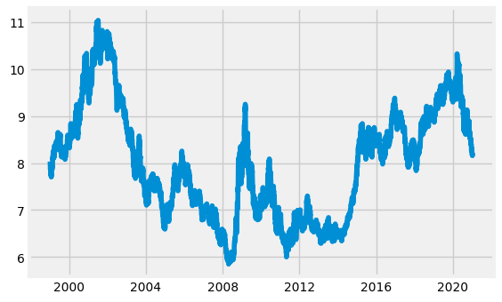

```python
import matplotlib.pyplot as plt
%matplotlib inline

plt.plot(fx['date'], fx['usdsek'])
```

The graph also shows that 'USD/SEK' seem to be trending in the longer run. This can be seen clearer by smoothing out the prices by a moving average.

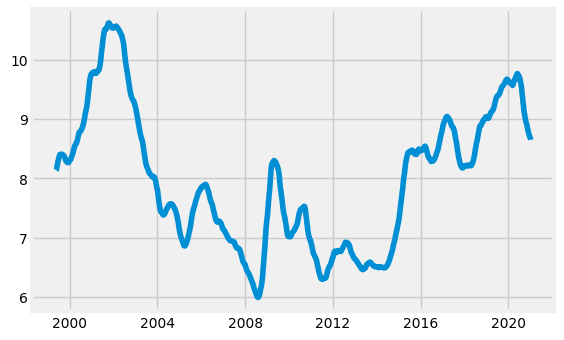

```python
plt.plot(fx['date'], fx['usdsek'].rolling(100).mean())
```

## Quarterly returns

To make it easier to create a bar plot (less bars) we'll get the quarterly returns.

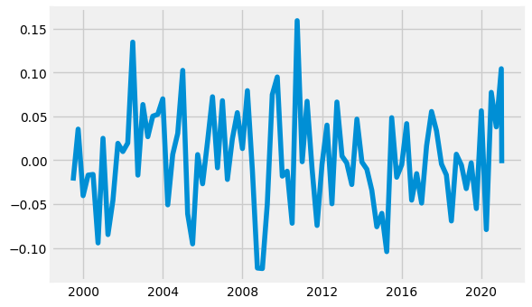

```python
import numpy as np

def quarterly(df, pricecol, datecol):
    lastdayofquarter = df.groupby(df.date.dt.to_period('Q'))['date'].max()
    df = df[df['date'].isin(lastdayofquarter)]
    prices = np.array(df[pricecol])
    ret =  prices[:-1] / prices[1:] - 1
    df = df.iloc[1:,] # Since no result for first obs.
    df['quarterly_ret'] = ret
    df['yearquarter'] = df['date'].dt.strftime('%Y-%q')
    df = df[['date','quarterly_ret']]
    return df

usdsek_q = quarterly(fx, 'usdsek', 'date')

fig, ax = plt.subplots()
ax.plot(usdsek_q['date'],usdsek_q['quarterly_ret'])
ax.tick_params(bottom=False)

plt.show()
```

```python
usdsek_q.head()
```

|  | date | quarterly_ret |
| --- | --- | --- |
| 127 | 1999-06-30 | -0.023152 |
| 193 | 1999-09-30 | 0.035412 |
| 258 | 1999-12-30 | -0.040329 |
| 324 | 2000-03-31 | -0.016927 |
| 389 | 2000-06-30 | -0.016138 |

```python
usdsek_q.tail(1)
```

|  | date | quarterly_ret |
| --- | --- | --- |
| 5698 | 2021-01-08 | -0.00337 |

Since first quarter of 2021 stopped at 8th of january we'll remove that month since we don't have the full month.

```python
usdsek_q = usdsek_q.iloc[:-1,]
```

```python
usdsek_q.head()
```

|  | date | quarterly_ret |
| --- | --- | --- |
| 127 | 1999-06-30 | -0.023152 |
| 193 | 1999-09-30 | 0.035412 |
| 258 | 1999-12-30 | -0.040329 |
| 324 | 2000-03-31 | -0.016927 |
| 389 | 2000-06-30 | -0.016138 |

```python
usdsek_q.tail()
```

|  | date | quarterly_ret |
| --- | --- | --- |
| 5436 | 2019-12-31 | 0.056274 |
| 5500 | 2020-03-31 | -0.078926 |
| 5562 | 2020-06-30 | 0.077260 |
| 5628 | 2020-09-30 | 0.037978 |
| 5693 | 2020-12-31 | 0.104177 |

```python
usdsek_q = usdsek_q[(usdsek_q['date']>'1999-12-30') & (usdsek_q['date']<'2021-01-01')]
```

```python
# Renaming for ease of use
usdsek = usdsek_q
usdsek.columns = usdsek.columns.str.replace('quarterly_ret', 'ret')

usdsek
```

|  | date | ret |
| --- | --- | --- |
| 324 | 2000-03-31 | -0.016927 |
| 389 | 2000-06-30 | -0.016138 |
| 454 | 2000-09-29 | -0.094124 |
| 519 | 2000-12-29 | 0.024969 |
| 584 | 2001-03-30 | -0.084593 |
| ... | ... | ... |
| 5436 | 2019-12-31 | 0.056274 |
| 5500 | 2020-03-31 | -0.078926 |
| 5562 | 2020-06-30 | 0.077260 |
| 5628 | 2020-09-30 | 0.037978 |
| 5693 | 2020-12-31 | 0.104177 |

84 rows × 2 columns

# Visualization

For the visualization i want to make I first want to separate positive and negative returns.

I'll do this by creating the new dataframes `pos` and `neg` where i'll replace negative returns with 0 for `pos` and vice versa.

```python
pos = usdsek.copy()
neg = usdsek.copy()
```

```python
pos = pos.reset_index()
pos.loc[pos['ret']<0,'ret'] = 0
pos.head()
```

|  | index | date | ret |
| --- | --- | --- | --- |
| 0 | 324 | 2000-03-31 | 0.000000 |
| 1 | 389 | 2000-06-30 | 0.000000 |
| 2 | 454 | 2000-09-29 | 0.000000 |
| 3 | 519 | 2000-12-29 | 0.024969 |
| 4 | 584 | 2001-03-30 | 0.000000 |

```python
neg = neg.reset_index()
neg.loc[neg['ret']>0,'ret'] = 0
neg.tail()
```

|  | index | date | ret |
| --- | --- | --- | --- |
| 79 | 5436 | 2019-12-31 | 0.000000 |
| 80 | 5500 | 2020-03-31 | -0.078926 |
| 81 | 5562 | 2020-06-30 | 0.000000 |
| 82 | 5628 | 2020-09-30 | 0.000000 |
| 83 | 5693 | 2020-12-31 | 0.000000 |

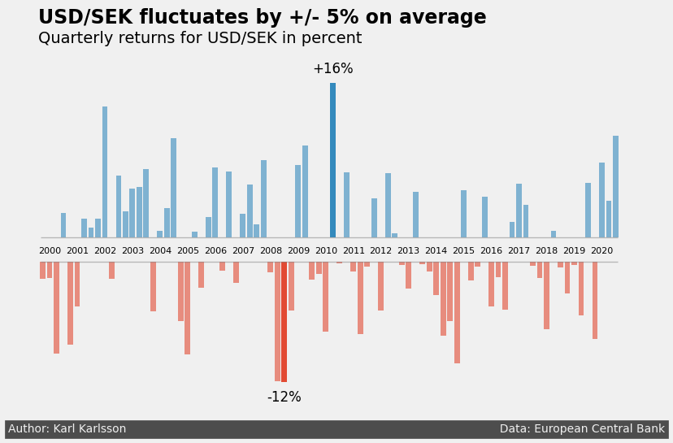

```python
from matplotlib.pyplot import style
style.use('fivethirtyeight')


fig, ax = plt.subplots(figsize=(9, 5))

# Add bar for positive returns
ax.bar(range(0,len(neg)),pos.ret, color='#348ABD',alpha=0.6)

# Add bar for negative returns
# Move to bottom to make space for new xlabels between bars
ax.bar(range(0,len(neg)),neg.ret, color='#E24A33',alpha=0.6, bottom=-0.025)

# Remove grid and x/y labels
ax.grid(b=False)
ax.set_yticklabels([])
ax.set_xticklabels([])

# Create new xlabels
years = usdsek.date.dt.strftime('%Y').unique() # Get unique years in data

# Set first x-coordinate and y-coordinate
x_coord = 1
y_coord = -0.016
for year in years :
    ax.text(x_coord, y_coord, str(year),size=8, ha='center')
    x_coord += 4

hlinemargin = 0.046
ax.axhline(y=-0.025, color='grey',alpha=0.5,linewidth=1, xmin=hlinemargin, xmax=1-hlinemargin)
ax.axhline(y=0.0, color='grey',alpha=0.5,linewidth=1, xmin=hlinemargin, xmax=1-hlinemargin)

# Get mean absolute return
meanabsret = np.mean(abs(usdsek['ret']))
meanabsret = str(int(round(meanabsret*100)))

# Add title
ax.text(s='USD/SEK fluctuates by +/- '+meanabsret+ '% on average',
        x=-0.7, y=.22, size=17, weight='bold')

# Add subtitle
ax.text(s='Quarterly returns for USD/SEK in percent',
        x=-0.7, y=0.2)

# Add author and source bar at bottom
ax.text(-5, -0.2,
        'Author: Karl Karlsson' + ' '*105 + 'Data: European Central Bank',
        color = '#f0f0f0', backgroundcolor = '#4d4d4d',
        size=10)

# Get best return
best = pos[pos['ret']==pos['ret'].max()]
beststring = '+' + str(int(round(best.ret.iloc[0]*100,0))) + '%'
ax.text(best.index[0], best.ret.iloc[0]+0.01, beststring,size=12, ha='center')
ax.bar(best.index,best.ret, color='#348ABD')


# Get worst return
worst = neg[neg['ret']==neg['ret'].min()]
worststring = '-' + str(abs(int(round(worst.ret.iloc[0]*100,0)))) + '%'
ax.text(worst.index[0], worst.ret.iloc[0]-0.045, worststring,size=12, ha='center')
ax.bar(worst.index,worst.ret, bottom=-0.025, color='#E24A33')

plt.show()
```

And there we have it! Quite nice if I may say so...